# Biostatistical Computing, PHC 6068

Linear Model

Zhiguang Huo (Caleb)

Monday September 13, 2017

# Outlines

- Linear regression

# linear regression model

$$Y = \beta_0 + \beta_1X_1 + \beta_2X_2 + \ldots + \beta_pX_p + \varepsilon, \text{with }\varepsilon \sim N(0, \sigma^2)$$

- Y: outcome variable or response.
- $X_1, X_2, \ldots, X_p$ are called predictors.
- $\beta_0, \beta_1, \ldots, \beta_p$ are called coefficient, for which we will estimate.

# Prostate cancer data

The data is from the book element of statistical learning

```r
library(ElemStatLearn)
str(prostate)
```

```
## 'data.frame':    97 obs. of  10 variables:
##  $ lcavol : num  -0.58 -0.994 -0.511 -1.204 0.751 ...
##  $ lweight: num  2.77 3.32 2.69 3.28 3.43 ...
##  $ age    : int  50 58 74 58 62 50 64 58 47 63 ...
##  $ lbph   : num  -1.39 -1.39 -1.39 -1.39 -1.39 ...
##  $ svi    : int  0 0 0 0 0 0 0 0 0 0 ...
##  $ lcp    : num  -1.39 -1.39 -1.39 -1.39 -1.39 ...
##  $ gleason: int  6 6 7 6 6 6 6 6 6 6 ...
##  $ pgg45  : int  0 0 20 0 0 0 0 0 0 0 ...
##  $ lpsa   : num  -0.431 -0.163 -0.163 -0.163 0.372 ...
##  $ train  : logi  TRUE TRUE TRUE TRUE TRUE TRUE ...
```

```r
prostate$train <- NULL
```

Explanation of these variables:

- lpsa: log PSA score
- lcavol: log cancer volume
- lweight: log prostate weight
- age: age
- lbph: log of the amount of benign prostatic hyperplasia
- svi: seminal vesicle invasion
- lcp: log of capsular penetration
- gleason: Cleason score
- pgg45: percent of Gleason scores 4 or 5.
- train: a logical vector indicating training data or testing data (ignore at this moment)

```r
head(prostate)
```

```
##       lcavol  lweight age      lbph svi       lcp gleason pgg45       lpsa
## 1 -0.5798185 2.769459  50 -1.386294   0 -1.386294       6     0 -0.4307829
## 2 -0.9942523 3.319626  58 -1.386294   0 -1.386294       6     0 -0.1625189
## 3 -0.5108256 2.691243  74 -1.386294   0 -1.386294       7    20 -0.1625189
## 4 -1.2039728 3.282789  58 -1.386294   0 -1.386294       6     0 -0.1625189
## 5  0.7514161 3.432373  62 -1.386294   0 -1.386294       6     0  0.3715636
## 6 -1.0498221 3.228826  50 -1.386294   0 -1.386294       6     0  0.7654678
```

# Exploratory analysis

- Distribution of each varaible.
- correlation between each pair of vairables.
- visualizing the scattered plot of each pair of variables.

# Distribution of each varaible – Histogram

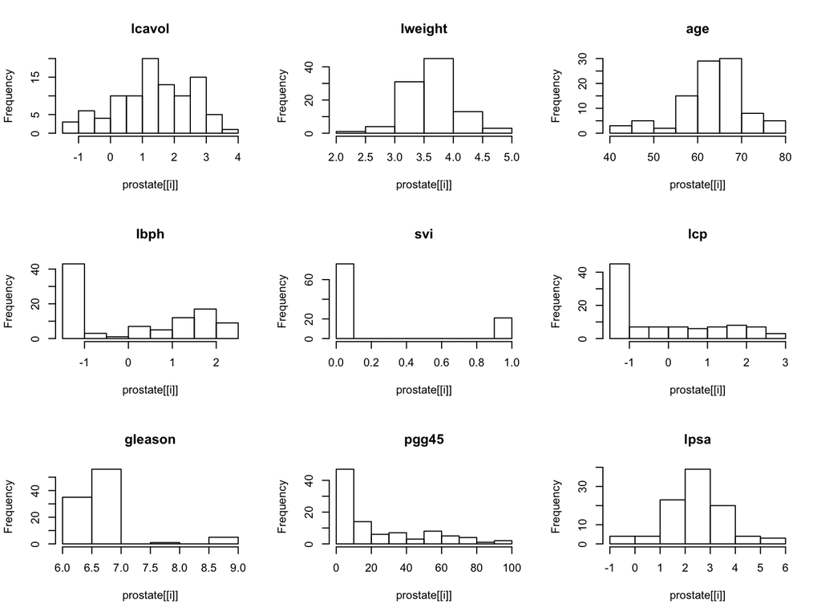

```r
par(mfrow=c(3,3))
for(i in 1:9){
  aname <- names(prostate)[i]
  hist(prostate[[i]], main=aname)
}
```

What can we learn from the histogram.

# Correlation between each pairs of variables

```r
cor_prostate <- cor(prostate)
max(cor_prostate[cor_prostate!=1])
```

```
## [1] 0.7519045
```

```r
maxID <- arrayInd(which(max(cor_prostate[cor_prostate!=1]) == cor_prostate), dim(cor_prostate))
names(prostate[maxID[1,]])
```

```
## [1] "pgg45"   "gleason"
```

# visualizing the scattered plot of each pair of variables.

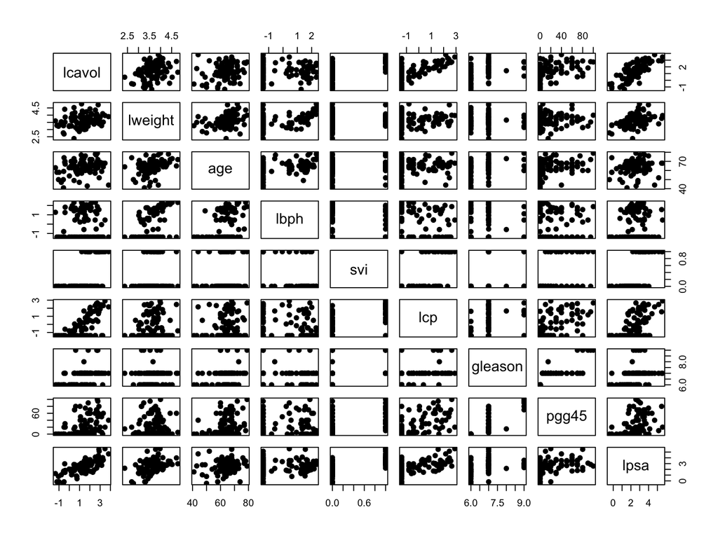

```r
pairs(prostate,pch=19)
```

# Fit linear regression model

- lm(formula, data): to fit a linear regression model.
  - formula: Symbolic description of the model (E.g Y ~ X1 + X2 + … + Xp)
    - Y is the response variable.
    - X’s are the predictors.
  - data: dataframe containing the variables in the model

```r
lm_prostate <- lm(lpsa ~ age + lweight, data = prostate)
lm_prostate
```

```
##
## Call:
## lm(formula = lpsa ~ age + lweight, data = prostate)
##
## Coefficients:
## (Intercept)          age      lweight
##   -1.897709     0.003318     1.147487
```

```r
class(lm_prostate)
```

```
## [1] "lm"
```

```r
names(lm_prostate)
```

```
##  [1] "coefficients"  "residuals"     "effects"       "rank"
##  [5] "fitted.values" "assign"        "qr"            "df.residual"
##  [9] "xlevels"       "call"          "terms"         "model"
```

# lm() utility functions

- coef(): get coefficient

```r
coef(lm_prostate)
```

```
##  (Intercept)          age      lweight
## -1.897708604  0.003318361  1.147487156
```

- fitted(): get fitted value, where fitted values are defined as $\hat{\beta_1}X_1 + \hat{\beta_2}X_2 + \ldots + \hat{\beta_p}X_p$

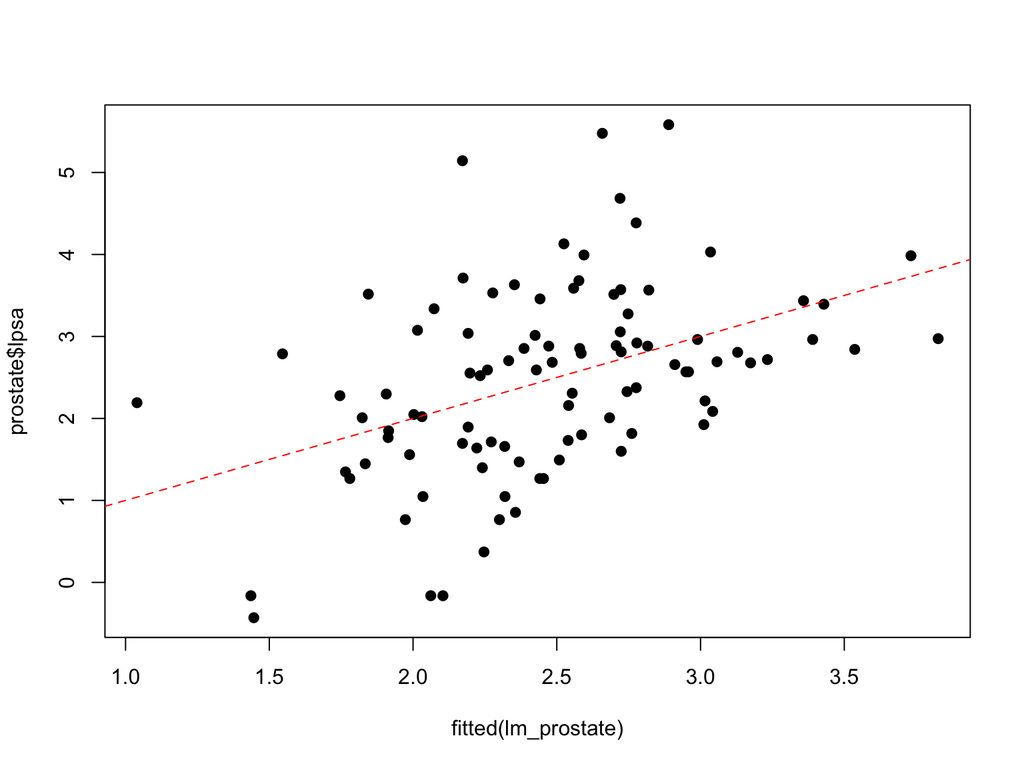

```r
plot(fitted(lm_prostate), prostate$lpsa, pch=19)
abline(a=0, b=1, lty=2, col="red")
```

- summary(): provide a summary of linear model fitting

```r
summary(lm_prostate)
```

```
##
## Call:
## lm(formula = lpsa ~ age + lweight, data = prostate)
##
## Residuals:
##     Min      1Q  Median      3Q     Max
## -2.2665 -0.6753 -0.0361  0.5317  2.9712
##
## Coefficients:
##              Estimate Std. Error t value Pr(>|t|)
## (Intercept) -1.897709   1.119033  -1.696   0.0932 .
## age          0.003318   0.015369   0.216   0.8295
## lweight      1.147487   0.267094   4.296 4.23e-05 ***
## ---
## Signif. codes:  0 '***' 0.001 '**' 0.01 '*' 0.05 '.' 0.1 ' ' 1
##
## Residual standard error: 1.051 on 94 degrees of freedom
## Multiple R-squared:  0.1882, Adjusted R-squared:  0.1709
## F-statistic: 10.89 on 2 and 94 DF,  p-value: 5.558e-05
```

- plot(): visualize linear model fitting

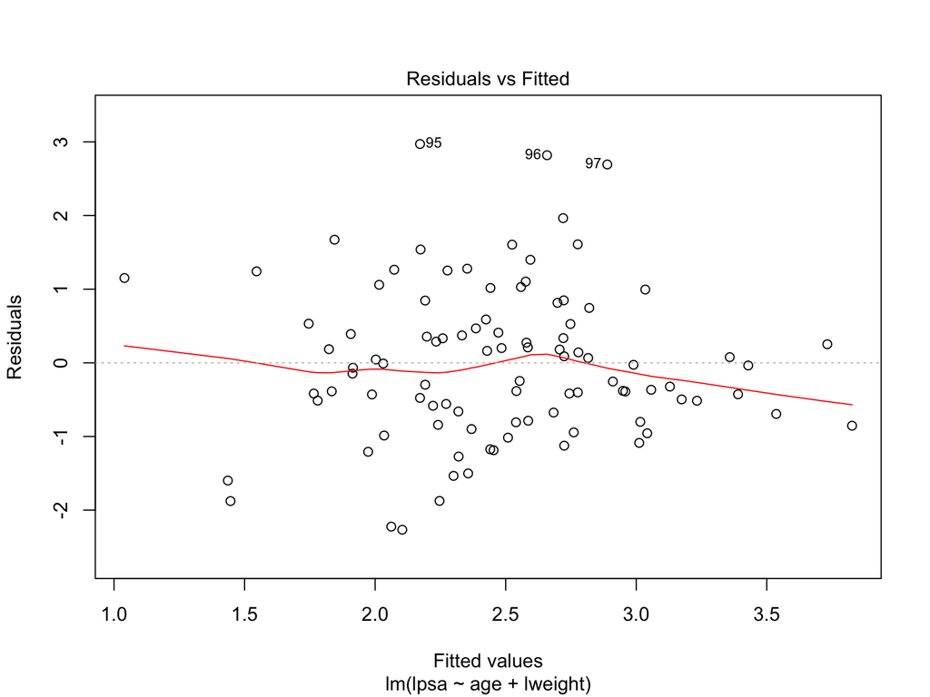

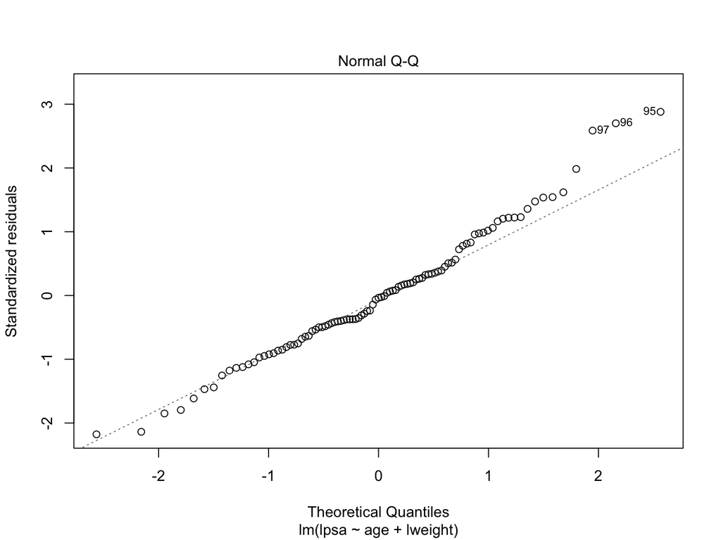

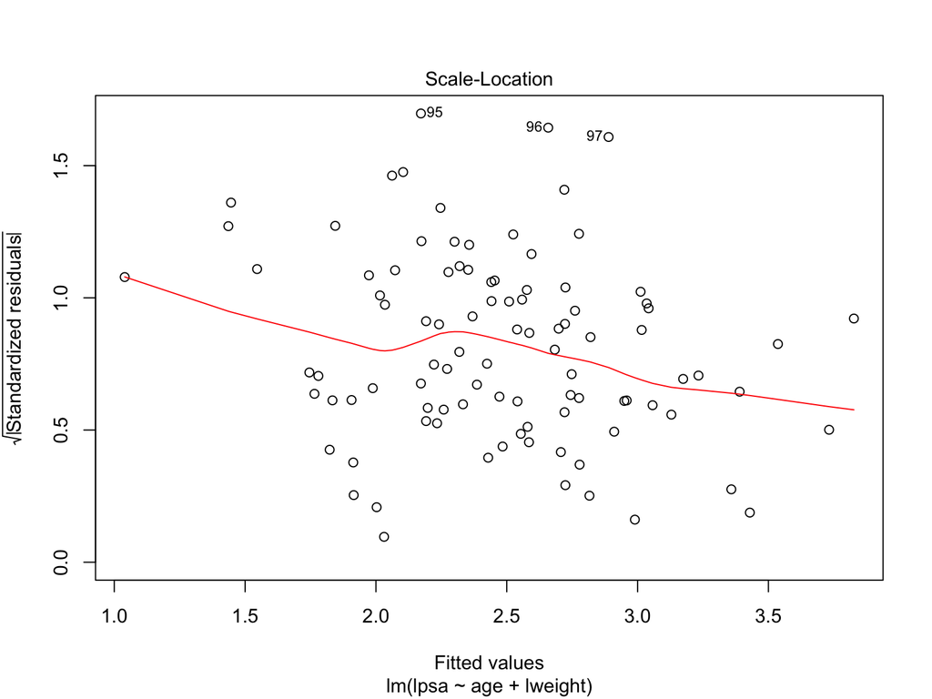

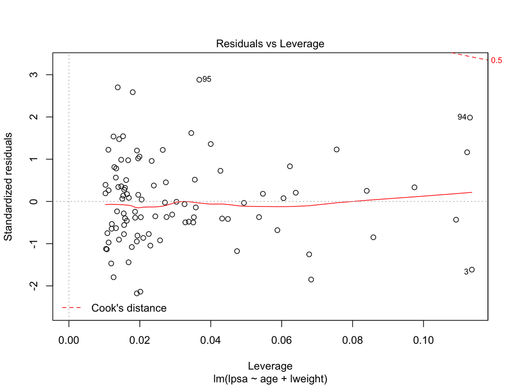

```r
plot(lm_prostate)
```

- predict(): predict a new subject.
  - If there is a new subject coming in with age 65 and lweight 4, what will be his predicted lpsa based our fitted linear model?

```r
anew <- data.frame(age = 65, lweight=4)
predict(object = lm_prostate, anew)
```

```
##        1
## 2.907934
```

- summary(): get a nice summary of linear model.

```r
summary(lm_prostate)
```

```
##
## Call:
## lm(formula = lpsa ~ age + lweight, data = prostate)
##
## Residuals:
##     Min      1Q  Median      3Q     Max
## -2.2665 -0.6753 -0.0361  0.5317  2.9712
##
## Coefficients:
##              Estimate Std. Error t value Pr(>|t|)
## (Intercept) -1.897709   1.119033  -1.696   0.0932 .
## age          0.003318   0.015369   0.216   0.8295
## lweight      1.147487   0.267094   4.296 4.23e-05 ***
## ---
## Signif. codes:  0 '***' 0.001 '**' 0.01 '*' 0.05 '.' 0.1 ' ' 1
##
## Residual standard error: 1.051 on 94 degrees of freedom
## Multiple R-squared:  0.1882, Adjusted R-squared:  0.1709
## F-statistic: 10.89 on 2 and 94 DF,  p-value: 5.558e-05
```

# Other formulas

# Fit a linear regression with interaction term

```r
lm_interaction <- lm(lpsa ~ lcavol + svi + lcavol:svi, data=prostate) ## : represent interaction term.
summary(lm_interaction)
```

```
##
## Call:
## lm(formula = lpsa ~ lcavol + svi + lcavol:svi, data = prostate)
##
## Residuals:
##     Min      1Q  Median      3Q     Max
## -1.6305 -0.5007  0.1266  0.4886  1.6847
##
## Coefficients:
##             Estimate Std. Error t value Pr(>|t|)
## (Intercept)  1.53970    0.12070  12.757  < 2e-16 ***
## lcavol       0.58640    0.08207   7.145 1.98e-10 ***
## svi          0.51385    0.67784   0.758    0.450
## lcavol:svi   0.06479    0.26614   0.243    0.808
## ---
## Signif. codes:  0 '***' 0.001 '**' 0.01 '*' 0.05 '.' 0.1 ' ' 1
##
## Residual standard error: 0.7595 on 93 degrees of freedom
## Multiple R-squared:  0.5806, Adjusted R-squared:  0.5671
## F-statistic: 42.92 on 3 and 93 DF,  p-value: < 2.2e-16
```

```r
lm_interaction2 <- lm(lpsa ~ lcavol * svi, data=prostate) ## * represent main effect and interaction
```

# Fit a linear regression model with all variables

```r
lm_all <- lm(lpsa ~ ., data=prostate) ## . Rest of all the other vaiables.
summary(lm_all)
```

```
##
## Call:
## lm(formula = lpsa ~ ., data = prostate)
##
## Residuals:
##      Min       1Q   Median       3Q      Max
## -1.76644 -0.35510 -0.00328  0.38087  1.55770
##
## Coefficients:
##              Estimate Std. Error t value Pr(>|t|)
## (Intercept)  0.181561   1.320568   0.137  0.89096
## lcavol       0.564341   0.087833   6.425 6.55e-09 ***
## lweight      0.622020   0.200897   3.096  0.00263 **
## age         -0.021248   0.011084  -1.917  0.05848 .
## lbph         0.096713   0.057913   1.670  0.09848 .
## svi          0.761673   0.241176   3.158  0.00218 **
## lcp         -0.106051   0.089868  -1.180  0.24115
## gleason      0.049228   0.155341   0.317  0.75207
## pgg45        0.004458   0.004365   1.021  0.31000
## ---
## Signif. codes:  0 '***' 0.001 '**' 0.01 '*' 0.05 '.' 0.1 ' ' 1
##
## Residual standard error: 0.6995 on 88 degrees of freedom
## Multiple R-squared:  0.6634, Adjusted R-squared:  0.6328
## F-statistic: 21.68 on 8 and 88 DF,  p-value: < 2.2e-16
```

# Model selection

- AIC, BIC
- forward selection and backward selection

# AIC, BIC

- AIC: Akaike information criterion
- $AIC = 2k - 2 \log ( {\hat{L}} )$
  - k: number of parameters.
  - $\hat{L}$: likelihood given the coefficient estimates

```r
AIC(lm_all)
```

```
## [1] 216.4952
```

- BIC: Bayesian information criterion
- $BIC = log(n)k - 2 \log ( {\hat{L}} )$

```r
BIC(lm_all)
```

```
## [1] 242.2423
```

# backward selection

- step() function can perform forward selection, backward selection or both.

```r
step(lm(lpsa ~ ., data=prostate)) ## default is backward selection
```

```
## Start:  AIC=-60.78
## lpsa ~ lcavol + lweight + age + lbph + svi + lcp + gleason +
##     pgg45
##
##           Df Sum of Sq    RSS     AIC
## - gleason  1    0.0491 43.108 -62.668
## - pgg45    1    0.5102 43.569 -61.636
## - lcp      1    0.6814 43.740 -61.256
## <none>                 43.058 -60.779
## - lbph     1    1.3646 44.423 -59.753
## - age      1    1.7981 44.857 -58.810
## - lweight  1    4.6907 47.749 -52.749
## - svi      1    4.8803 47.939 -52.364
## - lcavol   1   20.1994 63.258 -25.467
##
## Step:  AIC=-62.67
## lpsa ~ lcavol + lweight + age + lbph + svi + lcp + pgg45
##
##           Df Sum of Sq    RSS     AIC
## - lcp      1    0.6684 43.776 -63.176
## <none>                 43.108 -62.668
## - pgg45    1    1.1987 44.306 -62.008
## - lbph     1    1.3844 44.492 -61.602
## - age      1    1.7579 44.865 -60.791
## - lweight  1    4.6429 47.751 -54.746
## - svi      1    4.8333 47.941 -54.360
## - lcavol   1   21.3191 64.427 -25.691
##
## Step:  AIC=-63.18
## lpsa ~ lcavol + lweight + age + lbph + svi + pgg45
##
##           Df Sum of Sq    RSS     AIC
## - pgg45    1    0.6607 44.437 -63.723
## <none>                 43.776 -63.176
## - lbph     1    1.3329 45.109 -62.266
## - age      1    1.4878 45.264 -61.934
## - svi      1    4.1766 47.953 -56.336
## - lweight  1    4.6553 48.431 -55.373
## - lcavol   1   22.7555 66.531 -24.572
##
## Step:  AIC=-63.72
## lpsa ~ lcavol + lweight + age + lbph + svi
##
##           Df Sum of Sq    RSS     AIC
## <none>                 44.437 -63.723
## - age      1    1.1588 45.595 -63.226
## - lbph     1    1.5087 45.945 -62.484
## - lweight  1    4.3140 48.751 -56.735
## - svi      1    5.8509 50.288 -53.724
## - lcavol   1   25.9427 70.379 -21.119
```

```
##
## Call:
## lm(formula = lpsa ~ lcavol + lweight + age + lbph + svi, data = prostate)
##
## Coefficients:
## (Intercept)       lcavol      lweight          age         lbph
##     0.49473      0.54400      0.58821     -0.01644      0.10122
##         svi
##     0.71490
```

- You may notice that AIC from step() and AIC() are different
- AIC/BIC can be different for different methods up to a constant.

```r
stepDetails <- step(lm(lpsa ~ ., data=prostate), trace=0)$anova
stepDetails$AIC[2] - stepDetails$AIC[1]
```

```
## [1] -1.889365
```

```r
AIC(lm(lpsa ~ . - gleason, data=prostate)) - AIC(lm(lpsa ~ ., data=prostate))
```

```
## [1] -1.889365
```

# Regularized linear model

- ridge regression.
- lasso.

# ridge regression.

- Recap for linear model:
  - The least square estimator is uniformly minimum-variance unbiased estimator (UMVUE).
  - However, people cares about mean squared error (MSE) instead of purely unbiasness.
  - Linear regression has low bias (zero bias) but suffers from high variance. (Sometimes suffers collinearity issue.)
- Ridge regression:
  - sacrifice unbiasness a little bit but recude MSE.

$$\hat{\beta}^{ridge} = \arg\min_{\beta\in\mathbb{R}^p}
\sum_{i=1}^n(y_i - x_i^\top \beta)^2 + \lambda\sum_{j=1}^p \beta_j^2$$

- $\lambda \ge 0$ is a tuning parameter, controling the strength of the penalty term.
  - $\lambda =0$, we have original linear regression.
  - $\lambda = \infty$, we get $\hat{\beta}^{ridge} = 0$
  - For $\lambda$, we both fit a linear model and shrink the coefficients.

# ridge regression example

```r
library(MASS)
lm_ridge <- lm.ridge(lpsa ~ ., data=prostate, lambda=0); lm_ridge
```

```
##                    lcavol      lweight          age         lbph
##  0.181560862  0.564341279  0.622019787 -0.021248185  0.096712523
##          svi          lcp      gleason        pgg45
##  0.761673403 -0.106050939  0.049227933  0.004457512
```

```r
lm(lpsa ~ ., data=prostate)
```

```
##
## Call:
## lm(formula = lpsa ~ ., data = prostate)
##
## Coefficients:
## (Intercept)       lcavol      lweight          age         lbph
##    0.181561     0.564341     0.622020    -0.021248     0.096713
##         svi          lcp      gleason        pgg45
##    0.761673    -0.106051     0.049228     0.004458
```

# ridge regression example 2

```r
lm.ridge(lpsa ~ ., data=prostate, lambda=1)
```

```
##                  lcavol     lweight         age        lbph         svi
##  0.14716982  0.55209405  0.61998311 -0.02049376  0.09488234  0.74846397
##         lcp     gleason       pgg45
## -0.09399009  0.05227074  0.00424397
```

```r
lm.ridge(lpsa ~ ., data=prostate, lambda=Inf)
```

```
##            lcavol  lweight      age     lbph      svi      lcp  gleason
## 2.478387 0.000000 0.000000 0.000000 0.000000 0.000000 0.000000 0.000000
##    pgg45
## 0.000000
```

# lasso

- Problem with ridge regression: coefficient won’t be shrinked to exact 0.
- Lasso, the $l_1$ norm penalty will shrink come of the coefficients to exact zero.
  $$\hat{\beta}^{lasso} = \arg\min_{\beta \in \mathbb{R}^P} \|y - X\beta\|_2^2 + \lambda \sum_{j=1}^p |\beta_j|$$
- $\|\beta\|_1 = \sum_{j=1}^p |\beta_j|$ is called $l_1$ norm.
- $\lambda \ge 0$ is a tuning parameter, controling the strength of the penalty term.
  - $\lambda =0$, we have original linear regression.
  - $\lambda = \infty$, we get $\hat{\beta}^{ridge} = 0$
  - For $\lambda$, we both fit a linear model and shrink some coefficients to **exact zero**.

# lasso example

- lasso was implemented in R lars package.

```r
library(lars)
x <- as.matrix(prostate[,1:8])
y <- prostate[,9]
lassoFit <- lars(x, y) ## lar for least angle regression
coef(lassoFit, s=2, mode="lambda") ## get beta estimate when lambda = 2
```

```
##    lcavol   lweight       age      lbph       svi       lcp   gleason
## 0.4506712 0.2910916 0.0000000 0.0000000 0.3475427 0.0000000 0.0000000
##     pgg45
## 0.0000000
```

# visualize lasso path

- lasso solution (beta estimate is piecewise linear with respect to lambda)

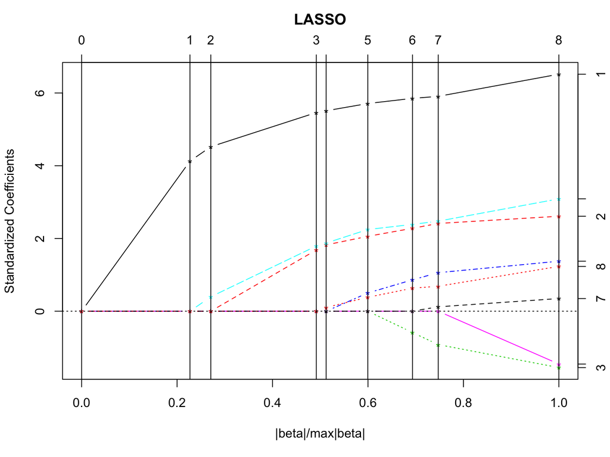

```r
plot(lassoFit)
```

# Intuition for lasso and ridge regression

- lasso regression equivalent forms.
  - in penalty form:
    $$\hat{\beta}^{lasso} = \arg\min_{\beta \in \mathbb{R}^P} \|y - X\beta\|_2^2 + \lambda \sum_{j=1}^p |\beta_j|$$
  - in constraint form:
    $$\hat{\beta}^{lasso} = \arg\min_{\beta \in \mathbb{R}^P} \|y - X\beta\|_2^2, s.t \sum_{j=1}^p |\beta_j| \le \mu$$
- ridge regression equivalent forms.
  - in penalty form:
    $$\hat{\beta}^{ridge} = \arg\min_{\beta\in\mathbb{R}^p}
    \sum_{i=1}^n(y_i - x_i^\top \beta)^2 + \lambda\sum_{j=1}^p \beta_j^2$$
  - in constraint form:
    $$\hat{\beta}^{ridge} = \arg\min_{\beta\in\mathbb{R}^p}
    \sum_{i=1}^n(y_i - x_i^\top \beta)^2, s.t \sum_{j=1}^p \beta_j^2 \le \mu$$

# Intuition for lasso and ridge regression

- Lasso: $\hat{\beta}^{lasso} = \arg\min_{\beta \in \mathbb{R}^P} \|y - X\beta\|_2^2, s.t \sum_{j=1}^p |\beta_j| \le \mu$
- Ridge: $\hat{\beta}^{ridge} = \arg\min_{\beta\in\mathbb{R}^p} \sum_{i=1}^n(y_i - x_i^\top \beta)^2, s.t \sum_{j=1}^p \beta_j^2 \le \mu$

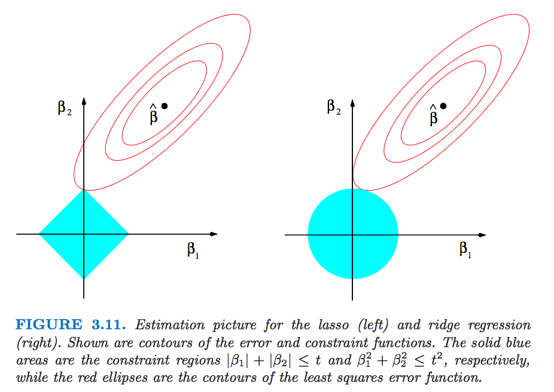

From book Element of Statistical Learning

# How to choose Tuning parameter

- cross validation, leave this for future lecture.